# Assignment 2: Optimization

Mike Noyes[^1]

08 February 2018

Abstract

The basis of this assignment is to understand optimization. There are three problems, each with multiple parts. Using what we have learned in class and information from the textbook, I have done my best to solve these problems.

# 1

PART A:

The Cauchy $(\theta,1)$ distribution has probability density:
$$p(x;\theta)=\cfrac{1}{\pi[1+(x-\theta)^2]}$$
We know that $x_{1},...,x_{n}$ are iid and that $(x-\theta)^2$ is the same thing as $(\theta-x)^2$. So the log likelihood function of $\theta$ based on the sample is as follows:
$$l(\theta)=\ln(\prod_{i=1}^n p(x_{i};\theta))=\ln(\prod_{i=1}^n \frac{1}{\pi[1+(x_{i}-\theta)^2]})=\sum_{i=1}^n \ln(\frac{1}{\pi[1+(x_{i}-\theta)^2]})=-n\ln\pi-\sum_{i=1}^n \ln[1+(\theta-x_{i})^2]$$
$$l^{'}(\theta)=\sum_{i=1}^n [ln(1+(\theta-x_{i})^2)]=-\sum_{i=1}^n \frac{2(\theta-x_{i})}{1+(\theta-x_{i})^2}=-2\sum_{i=1}^n \frac{(\theta-x_{i})}{1+(\theta-x_{i})^2}$$
$$l^{''}(\theta)=-2\sum_{i=1}^n \frac{(1)(1+(\theta-x_{i})^2)-2(\theta-x_{i})^2}{1+(\theta-x_{i})^2}=-2\sum_{i=1}^n \frac{1-(\theta-x_{i})^2}{[1+(\theta-x_{i})^2]^2}$$
$$I(\theta)=n\int\frac{[p^{'}(x)]^2}{p(x)}=\frac{4n}{\pi} \int_{-\infty}^{\infty}\frac{x^2dx}{(1+x^2)^3}$$
If we set x equal to $\tan(y)$, and realize that the its derivative is $\sec^2(y)$, we get
$$I(\theta)=\frac{4n}{\pi} \int_{-\frac{\pi}{2}}^{\frac{\pi}{2}}\frac{\tan^2(y)d(\tan(y))}{(1+tan^2(y))^3}=\frac{4n}{\pi}\int_{-\frac{\pi}{2}}^{\frac{\pi}{2}}\frac{\tan^2(y)}{(\frac{1}{\sec^2(y)})^3}(\frac{1}{\sec^2(y)})dt$$
Note that $tan^2(y)=sin^2(y)/cos^2(y)$ and $1/sec^2(y)=cos^2(y)$, so
$$I(\theta)=\frac{4n}{\pi}\int_{-\frac{\pi}{2}}^{\frac{\pi}{2}}\frac{\sin^2(y)}{\cos^2(y)}\cos^4(y)dt=\frac{4n}{\pi}\int_{-\frac{\pi}{2}}^{\frac{\pi}{2}}\sin^2(y)\cos^2(y)dt=\frac{4n}{\pi}*\frac{\pi}{8}=\frac{n}{2}$$

PART B:

x <- c(1.77, -0.23, 2.76, 3.80, 3.47, 56.75, -1.34, 4.24, -2.44 ,3.29, 3.71, -2.40, 4.53, -0.07, -1.05, -13.87, -2.53, -1.75)

mean(x) = 3.257778

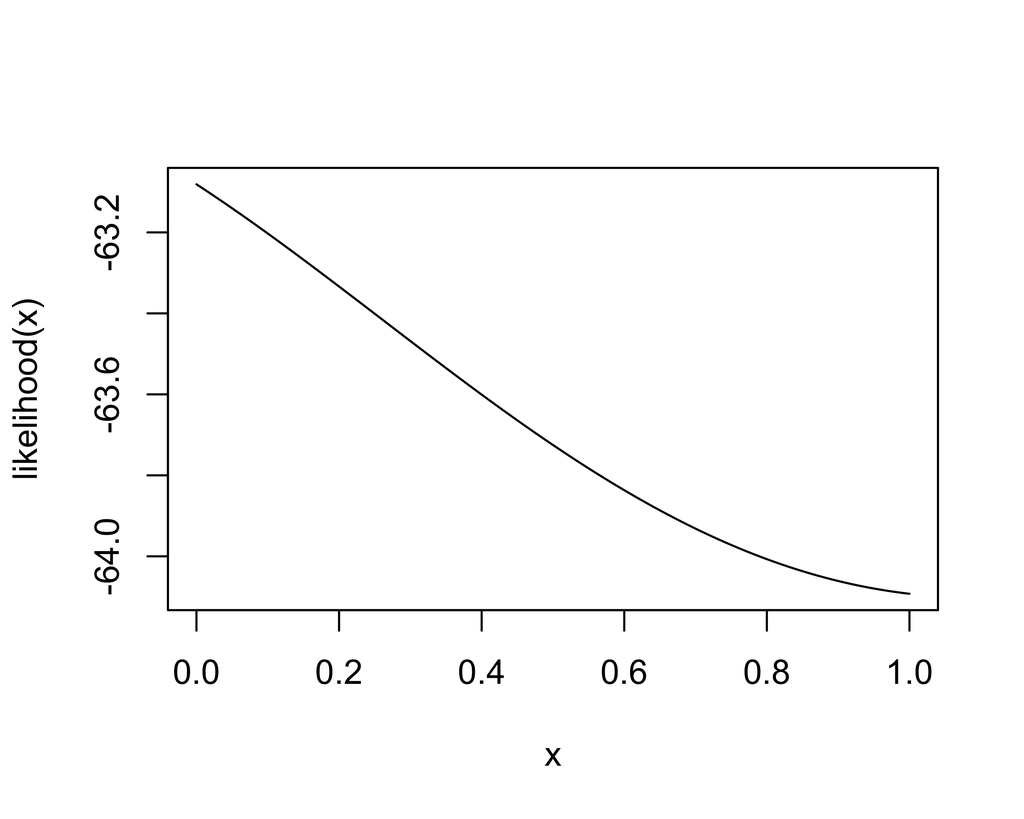

```r
logp <- function(theta, x) {
  -log(pi)-log(1+(theta-x)^2)
}
likelihood <- function(theta) {
  logp(theta,1.77) + logp(theta,-0.23) + logp(theta,2.76) + logp(theta,3.80) + logp(theta,3.47) + logp(theta,56.75) + logp(theta,-1.34) + logp(theta,4.24) + logp(theta,-2.44) + logp(theta,3.29) + logp(theta,3.71) + logp(theta,-2.40) + logp(theta,4.53) + logp(theta,-0.07) + logp(theta,-1.05) + logp(theta,-13.87) + logp(theta,-2.53) + logp(theta,-1.75)
}
curve(likelihood)
```

```r
startingpoint_negative11 <- nlminb(-11, likelihood)
startingpoint_negative11
```

```
## $par
## [1] -1.603184e+32
##
## $objective
## [1] -2690.175
##
## $convergence
## [1] 1
##
## $iterations
## [1] 150
##
## $evaluations
## function gradient
##      152      151
##
## $message
## [1] "iteration limit reached without convergence (10)"
```

```r
startingpoint_negative1 <- nlminb(-1, likelihood)
startingpoint_negative1
```

```
## $par
## [1] -2.832684e+32
##
## $objective
## [1] -2710.667
##
## $convergence
## [1] 1
##
## $iterations
## [1] 150
##
## $evaluations
## function gradient
##      153      151
##
## $message
## [1] "iteration limit reached without convergence (10)"
```

```r
startingpoint_0 <- nlminb(0, likelihood)
startingpoint_0
```

```
## $par
## [1] 1.09273
##
## $objective
## [1] -64.10186
##
## $convergence
## [1] 0
##
## $iterations
## [1] 4
##
## $evaluations
## function gradient
##        6        7
##
## $message
## [1] "relative convergence (4)"
```

```r
startingpoint_1.5 <- nlminb(1.5, likelihood)
startingpoint_1.5
```

```
## $par
## [1] 1.09273
##
## $objective
## [1] -64.10186
##
## $convergence
## [1] 0
##
## $iterations
## [1] 5
##
## $evaluations
## function gradient
##        6        8
##
## $message
## [1] "relative convergence (4)"
```

```r
startingpoint_4 <- nlminb(4, likelihood)
startingpoint_4
```

```
## $par
## [1] 9.386171e+31
##
## $objective
## [1] -2670.903
##
## $convergence
## [1] 1
##
## $iterations
## [1] 150
##
## $evaluations
## function gradient
##      152      151
##
## $message
## [1] "iteration limit reached without convergence (10)"
```

```r
startingpoint_4.7 <- nlminb(4.7, likelihood)
startingpoint_4.7
```

```
## $par
## [1] 9.257391e+31
##
## $objective
## [1] -2670.405
##
## $convergence
## [1] 1
##
## $iterations
## [1] 150
##
## $evaluations
## function gradient
##      153      151
##
## $message
## [1] "iteration limit reached without convergence (10)"
```

```r
startingpoint_7 <- nlminb(7, likelihood)
startingpoint_7
```

```
## $par
## [1] 7.515057e+31
##
## $objective
## [1] -2662.899
##
## $convergence
## [1] 1
##
## $iterations
## [1] 150
##
## $evaluations
## function gradient
##      152      151
##
## $message
## [1] "iteration limit reached without convergence (10)"
```

```r
startingpoint_8 <- nlminb(8, likelihood)
startingpoint_8
```

```
## $par
## [1] 1.256138e+32
##
## $objective
## [1] -2681.393
##
## $convergence
## [1] 1
##
## $iterations
## [1] 150
##
## $evaluations
## function gradient
##      152      151
##
## $message
## [1] "iteration limit reached without convergence (10)"
```

```r
startingpoint_38 <- nlminb(38, likelihood)
startingpoint_38
```

```
## $par
## [1] 3.419116e+32
##
## $objective
## [1] -2717.441
##
## $convergence
## [1] 1
##
## $iterations
## [1] 150
##
## $evaluations
## function gradient
##      152      151
##
## $message
## [1] "iteration limit reached without convergence (10)"
```

```r
startingpoint_mean <- nlminb(3.257778,likelihood)
startingpoint_mean
```

```
## $par
## [1] 8.595074e+31
##
## $objective
## [1] -2667.733
##
## $convergence
## [1] 1
##
## $iterations
## [1] 150
##
## $evaluations
## function gradient
##      152      151
##
## $message
## [1] "iteration limit reached without convergence (10)"
```

Comparing the results shows that the sample mean is not a great starting point. Zero is the best starting point.

PART C:

```r
fixedpointiterations <- function(fun, x0, tol=.00000001, niter=500){
  oldxvalue <- x0
  newxvalue <- fun(oldxvalue)
  for(i in 1:niter){
    oldxvalue <- newxvalue
    newxvalue <- fun(oldxvalue)
    if(abs((newxvalue - oldxvalue)) < tol)
      return(newxvalue)
  }
  stop
  return(NULL)
}

derivativelogp <- function(theta, x) {
  -(2 * (theta-x) / (1+(theta-x)^2))
}

Galpha1 <- function(theta) {
  1 * (derivativelogp(theta, 1.77) + derivativelogp(theta, -.23) + derivativelogp(theta, 2.76) + derivativelogp(theta, 3.80) + derivativelogp(theta, 3.47) + derivativelogp(theta, 56.75) + derivativelogp(theta, -1.34) + derivativelogp(theta, 4.24) + derivativelogp(theta, -2.44) + derivativelogp(theta, 3.29) + derivativelogp(theta, 3.71) + derivativelogp(theta, -2.40) + derivativelogp(theta, 4.53) + derivativelogp(theta, -.07) + derivativelogp(theta, -1.05) + derivativelogp(theta, -13.87) + derivativelogp(theta, -2.53) + derivativelogp(theta, -1.75)) + theta
}

fix1_negative11 <- fixedpointiterations(Galpha1, -11)
fix1_negative11
```

```
## [1] -0.5914735
```

```r
fix1_negative1 <- fixedpointiterations(Galpha1, -1)
fix1_negative1
```

```r
fix1_0 <- fixedpointiterations(Galpha1, 0)
fix1_0
```

```r
fix1_1.5 <- fixedpointiterations(Galpha1, 1.5)
fix1_1.5
```

```r
fix1_4 <- fixedpointiterations(Galpha1, 4)
fix1_4
```

```r
fix1_4.7 <- fixedpointiterations(Galpha1, 4.7)
fix1_4.7
```

```r
fix1_7 <- fixedpointiterations(Galpha1, 7)
fix1_7
```

```r
fix1_8 <- fixedpointiterations(Galpha1, 8)
fix1_8
```

```r
fix1_38 <- fixedpointiterations(Galpha1, 38)
fix1_38
```

```r
Galpha0.64 <- function(theta) {
  0.64 * (derivativelogp(theta, 1.77) + derivativelogp(theta, -.23) + derivativelogp(theta, 2.76) + derivativelogp(theta, 3.80) + derivativelogp(theta, 3.47) + derivativelogp(theta, 56.75) + derivativelogp(theta, -1.34) + derivativelogp(theta, 4.24) + derivativelogp(theta, -2.44) + derivativelogp(theta, 3.29) + derivativelogp(theta, 3.71) + derivativelogp(theta, -2.40) + derivativelogp(theta, 4.53) + derivativelogp(theta, -.07) + derivativelogp(theta, -1.05) + derivativelogp(theta, -13.87) + derivativelogp(theta, -2.53) + derivativelogp(theta, -1.75)) + theta
}

fix0.64_negative11 <- fixedpointiterations(Galpha0.64, -11)
fix0.64_negative11
```

```
## [1] -0.5914735
```

```r
fix0.64_negative1 <- fixedpointiterations(Galpha0.64, -1)
fix0.64_negative1
```

```
## [1] -0.5914735
```

```r
fix0.64_0 <- fixedpointiterations(Galpha0.64, 0)
fix0.64_0
```

```
## [1] -0.5914735
```

```r
fix0.64_1.5 <- fixedpointiterations(Galpha0.64, 1.5)
fix0.64_1.5
```

[output not shown]

```r
fix0.64_4 <- fixedpointiterations(Galpha0.64, 4)
fix0.64_4
```

```
## [1] -0.5914735
```

```r
fix0.64_4.7 <- fixedpointiterations(Galpha0.64, 4.7)
fix0.64_4.7
```

```
## [1] -0.5914735
```

```r
fix0.64_7 <- fixedpointiterations(Galpha0.64, 7)
fix0.64_7
```

[output not shown]

```r
fix0.64_8 <- fixedpointiterations(Galpha0.64, 8)
fix0.64_8
```

```
## [1] -0.5914735
```

```r
fix0.64_38 <- fixedpointiterations(Galpha0.64, 38)
fix0.64_38
```

[output not shown]

```r
Galpha0.25 <- function(theta) {
  0.25 * (derivativelogp(theta, 1.77) + derivativelogp(theta, -.23) + derivativelogp(theta, 2.76) + derivativelogp(theta, 3.80) + derivativelogp(theta, 3.47) + derivativelogp(theta, 56.75) + derivativelogp(theta, -1.34) + derivativelogp(theta, 4.24) + derivativelogp(theta, -2.44) + derivativelogp(theta, 3.29) + derivativelogp(theta, 3.71) + derivativelogp(theta, -2.40) + derivativelogp(theta, 4.53) + derivativelogp(theta, -.07) + derivativelogp(theta, -1.05) + derivativelogp(theta, -13.87) + derivativelogp(theta, -2.53) + derivativelogp(theta, -1.75)) + theta
}

fix0.25_negative11 <- fixedpointiterations(Galpha0.25, -11)
fix0.25_negative11
```

```
## [1] -0.5914735
```

```r
fix0.25_negative1 <- fixedpointiterations(Galpha0.25, -1)
fix0.25_negative1
```

```
## [1] -0.5914735
```

```r
fix0.25_0 <- fixedpointiterations(Galpha0.25, 0)
fix0.25_0
```

```
## [1] -0.5914735
```

```r
fix0.25_1.5 <- fixedpointiterations(Galpha0.25, 1.5)
fix0.25_1.5
```

```
## [1] 3.021345
```

```r
fix0.25_4 <- fixedpointiterations(Galpha0.25, 4)
fix0.25_4
```

```
## [1] 3.021345
```

```r
fix0.25_4.7 <- fixedpointiterations(Galpha0.25, 4.7)
fix0.25_4.7
```

```
## [1] 3.021345
```

```r
fix0.25_7 <- fixedpointiterations(Galpha0.25, 7)
fix0.25_7
```

```
## [1] 3.021345
```

```r
fix0.25_8 <- fixedpointiterations(Galpha0.25, 8)
fix0.25_8
```

```
## [1] 3.021345
```

```r
fix0.25_38 <- fixedpointiterations(Galpha0.25, 38)
fix0.25_38
```

```
## [1] 3.021345
```

PART D:

```r
derivativelogp <- function(theta, x) {
  -( 2 * (theta - x) / (1 + (theta - x)^2))
}

loglikelihood <- function(theta) {
  -(logp(theta, 1.77) + logp(theta, -.23) + logp(theta, 2.76) + logp(theta, 3.80) + logp(theta, 3.47) + logp(theta, 56.75) + logp(theta, -1.34) + logp(theta, 4.24) + logp(theta, -2.44) + logp(theta, 3.29) + logp(theta, 3.71) + logp(theta, -2.40) + logp(theta, 4.53) + logp(theta, -.07) + logp(theta, -1.05) + logp(theta, -13.87) + logp(theta, -2.53) + logp(theta, -1.75))
}

derivativeloglikelihood <- function(theta) {
  (derivativelogp(theta, 1.77) + derivativelogp(theta, -0.23) + derivativelogp(theta, 2.76) +
  derivativelogp(theta, 3.80) + derivativelogp(theta, 3.47) + derivativelogp(theta, 56.75) +
  derivativelogp(theta, -1.34) + derivativelogp(theta, 4.24) + derivativelogp(theta, -2.44) +
  derivativelogp(theta, 3.29) + derivativelogp(theta, 3.71) + derivativelogp(theta, -2.40) +
  derivativelogp(theta, 4.53) + derivativelogp(theta, -0.07) + derivativelogp(theta, -1.05) +
  derivativelogp(theta, -13.87) + derivativelogp(theta, -2.53) + derivativelogp(theta, -1.75))
}

A <- function(x) diag(9, nrow = length(x))

startingpoint_negative11 <- nlminb(-11, loglikelihood, derivativeloglikelihood, A)
startingpoint_negative11
```

```
## $par
## [1] -11
##
## $objective
## [1] 110.0773
##
## $convergence
## [1] 1
##
## $iterations
## [1] 1
##
## $evaluations
## function gradient
##       22        1
##
## $message
## [1] "false convergence (8)"
```

```r
startingpoint_negative1 <- nlminb(-1, loglikelihood, derivativeloglikelihood, A)
startingpoint_negative1
```

```
## $par
## [1] -1
##
## $objective
## [1] 62.90536
##
## $convergence
## [1] 1
##
## $iterations
## [1] 1
##
## $evaluations
## function gradient
##       23        1
##
## $message
## [1] "false convergence (8)"
```

```r
startingpoint_0 <- nlminb(0, loglikelihood, derivativeloglikelihood, A)
startingpoint_0
```

```
## $par
## [1] 0
##
## $objective
## [1] 63.08115
##
## $convergence
## [1] 1
##
## $iterations
## [1] 1
##
## $evaluations
## function gradient
##      200        1
##
## $message
## [1] "function evaluation limit reached without convergence (9)"
```

```r
startingpoint_1.5 <- nlminb(1.5, loglikelihood, derivativeloglikelihood, A)
startingpoint_1.5
```

```
## $par
## [1] 1.5
##
## $objective
## [1] 63.94583
##
## $convergence
## [1] 1
##
## $iterations
## [1] 1
##
## $evaluations
## function gradient
##       23        1
##
## $message
## [1] "false convergence (8)"
```

```r
startingpoint_4 <- nlminb(4, loglikelihood, derivativeloglikelihood, A)
startingpoint_4
```

```
## $par
## [1] 4
##
## $objective
## [1] 65.36038
##
## $convergence
## [1] 1
##
## $iterations
## [1] 1
##
## $evaluations
## function gradient
##       23        1
##
## $message
## [1] "false convergence (8)"
```

```r
startingpoint_4.7 <- nlminb(4.7, loglikelihood, derivativeloglikelihood, A)
startingpoint_4.7
```

```
## $par
## [1] 4.7
##
## $objective
## [1] 70.85886
##
## $convergence
## [1] 1
##
## $iterations
## [1] 1
##
## $evaluations
## function gradient
##       23        1
##
## $message
## [1] "false convergence (8)"
```

```r
startingpoint_7 <- nlminb(7, loglikelihood, derivativeloglikelihood, A)
startingpoint_7
```

```
## $par
## [1] 7
##
## $objective
## [1] 89.29679
##
## $convergence
## [1] 1
##
## $iterations
## [1] 1
##
## $evaluations
## function gradient
##       23        1
##
## $message
## [1] "false convergence (8)"
```

```r
startingpoint_8 <- nlminb(8, loglikelihood, derivativeloglikelihood, A)
startingpoint_8
```

```
## $par
## [1] 8
##
## $objective
## [1] 94.96757
##
## $convergence
## [1] 1
##
## $iterations
## [1] 1
##
## $evaluations
## function gradient
##       23        1
##
## $message
## [1] "false convergence (8)"
```

```r
startingpoint_38 <- nlminb(38, loglikelihood, derivativeloglikelihood, A)
startingpoint_38
```

```
## $par
## [1] 38
##
## $objective
## [1] 149.8628
##
## $convergence
## [1] 1
##
## $iterations
## [1] 1
##
## $evaluations
## function gradient
##       20        1
##
## $message
## [1] "false convergence (8)"
```

PART E:

# 2

PART A:

$$p(x;\theta)=\frac{1-\cos(x_i-\theta)}{2\pi}$$
$$l(\theta)=\prod_{i=1}^n \frac{1-\cos(x_i-\theta)}{2\pi}=\sum_{i=1}^n \ln{(1-\cos(x_i-\theta))}-n\ln{2\pi}$$
Since the derivative of cos(x) is -sin(x), so the derivative of the likelihood function is as follows:
$$l^{'}(\theta)=\sum_{i=1}^n \frac{\sin(\theta-x_i)}{1-\cos(\theta-x_i)}$$
The second derivative is:
$$l^{''}(\theta)=\sum\limits_{i=1}^n \frac{\cos(\theta-x_i)(1-cos(\theta-x_i))-\sin^2(\theta-x_i)}{(1-\cos(\theta-x_i))^2}=\sum_{i=1}^n \frac{\cos(\theta-x_i)-1}{(1-\cos(\theta-x_i))^2}=sum_{i=1}^n \frac{1}{\cos(theta-x_i)}$$

x <- c(3.91, 4.85, 2.28, 4.06, 3.70, 4.04, 5.46, 3.53, 2.28, 1.96, 2.53, 3.88, 2.22, 3.47, 4.82, 2.46, 2.99, 2.54, 0.52)

mean(x) = 3.236842

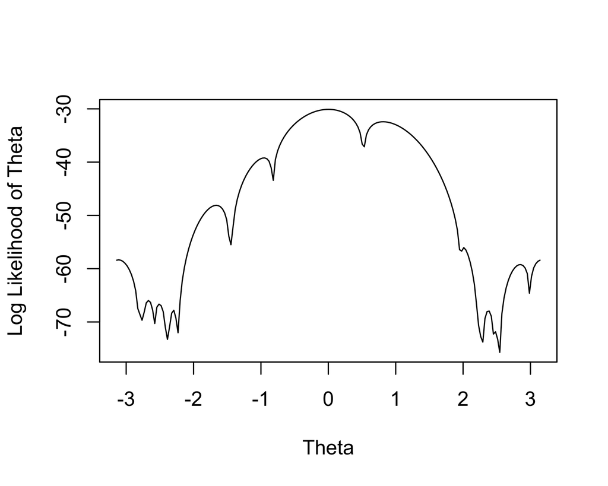

```r
x <- c(3.91, 4.85, 2.28, 4.06, 3.70, 4.04, 5.46, 3.53, 2.28, 1.96, 2.53, 3.88, 2.22, 3.47, 4.82, 2.46, 2.99, 2.54, 0.52)

theta <- seq(-pi,pi, by=pi/100)
loglikelihood <- function(x, theta) {
  sapply(theta, function(theta) sum(log((1-cos(x-theta))/(2*pi))))
}
plot(theta,loglikelihood(x,theta),xlab="Theta",ylab="Log Likelihood of Theta",type="l")
```

PART B:

$$E[X|\theta]=\frac{1}{2\pi}\int_{0}^{2\pi}x*({1-\cos(x-\theta)})dx=\pi-\frac{1}{2\pi}\int_{0}^{2\pi}x*\cos(x-\theta)dx$$
We now need to integrate by parts. This yields the following:
$$\int_{0}^{2\pi}x*\cos(x-\theta)dx=x*\sin(x-\theta)|_{0}^{2\pi}-\int_{0}^{2\pi}sin(x-\theta)dx=2\pi\sin(2\pi-\theta)=2\pi\sin(-\theta)=2\pi\sin(\theta)$$
Because $sin(2\pi+x)=sin(x)$ and $\sin(-x)=sin(x)$. So, we have:
$$E[X|\theta]=\pi-\sin(\theta)$$
Finally, the Method of Moments estimator of $\theta$ is $E[X|\theta]=\overline{X}=\pi-\sin(\theta)\iff\theta_{moment}=\arcsin(\pi-\overline{X})$

```r
thetamethodofmomentsestimator <- asin(pi-3.236842)
thetamethodofmomentsestimator
```

```
## [1] -0.09539396
```

PART C:

```r
x <- c(3.91, 4.85, 2.28, 4.06, 3.70, 4.04, 5.46, 3.53, 2.28, 1.96, 2.53, 3.88, 2.22, 3.47, 4.82, 2.46, 2.99, 2.54, 0.52)

NRmethod <- function(p,q,x0,b,maximumvalue) {
  x1 <- x0-p(x0)/q(x0)
  iteration <- 1
  while(abs(x1-x0) > b & iteration < maximumvalue) {
    x0 <- x1
    x1 <- x0-p(x0)/q(x0)
    iteration <- iteration+1
  }
  return(x1)
}

derivativeloglikilihood <- function(theta) {
  return(-sum(sin(-theta)/(1-cos(x-theta))))
}

secondderivativeloglikelihood <- function(theta) {
  return(-sum(1/(1-cos(x-theta))))
}

NRmethod(derivativeloglikelihood, secondderivativeloglikelihood, thetamethodofmomentsestimator, 0.00000001, 500)
```

```
## [1] -0.5914733
```

PART D:

```r
NRmethod(derivativeloglikelihood, secondderivativeloglikelihood, -2.7, 0.00000001, 500)
```

```
## [1] -2.583716
```

```r
NRmethod(derivativeloglikelihood, secondderivativeloglikelihood, 2.7, 0.00000001, 500)
```

```
## [1] 2.972758
```

# 3

PART A:

```r
beetles <- data.frame(
  days    = c(0,  8,  28,  41,  63,  69,   97, 117,  135,  154),
  beetles = c(2, 47, 192, 256, 768, 896, 1120, 896, 1184, 1024)
)

growthfunc <- function(t, K, r) {
  2*K/(2+(K-2)*exp(-r*t))
}

n <- nls(beetles~growthfunc(days, K, r), data=beetles, start=list(K=1030, r=0.2),trace=T)
```

```
## 581379.6 :  1030.0    0.2
## 140584 :  947.1168989   0.1418781
## 79987.33 :  1014.9597754    0.1241012
## 73588.69 :  1043.9681300    0.1191291
## 73423.65 :  1048.8120264    0.1184152
## 73419.81 :  1049.3141568    0.1182932
## 73419.7 :  1049.3916987    0.1182726
## 73419.7 :  1049.4046222    0.1182691
## 73419.7 :  1049.4068005    0.1182685
```

```r
n
```

```
## Nonlinear regression model
##   model: beetles ~ growthfunc(days, K, r)
##    data: beetles
##         K         r
## 1049.4068    0.1183
##  residual sum-of-squares: 73420
##
## Number of iterations to convergence: 8
## Achieved convergence tolerance: 5.433e-06
```

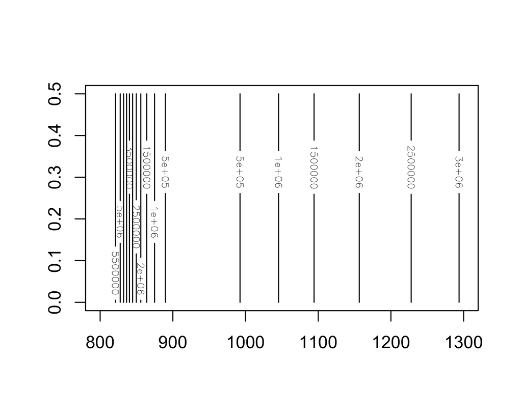

```r
days    = c(0,  8,  28,  41,  63,  69,   97, 117,  135,  154)
beetles = c(2, 47, 192, 256, 768, 896, 1120, 896, 1184, 1024)

sumofsquareerrors <- function(K, r) {
  return(sum((beetles - 2*K / (2 + (K - 2) * exp(-r * days)))^2))
}

n <- matrix(0, 100, 100, byrow=T)
for(i in 1:100) {
  for(j in 1:100) {
    K <- 800 + 5 * j
    r <- 0.005 * j
    n[j,i] <- sumofsquareerrors(K, r)
  }
}
K <- seq( 800, 1300, length.out=100)
r <- seq(   0,  0.5, length.out=100)
contour(K, r, n)
```

[^1]: michael.noyes@uconn.edu; Master’s student at Department of Mathematics, University of Connecticut.